# Final project

Dongyi Qiu

2022-03-04

# Introduction

1. Is the median age related to the affection rate and the death rate?
2. What is the relationship between the gdp and the affection rate and the death rate.
3. I will go further to explore the interaction terms.

# Data cleaning and exploration

```r
covid.raw=read.csv("C:/Users/13067/Desktop/owid-covid-data.csv")
```

```r
head(covid.raw)
```

```
##   iso_code continent    location       date total_cases new_cases
## 1      AFG      Asia Afghanistan 2020-02-24           5         5
## 2      AFG      Asia Afghanistan 2020-02-25           5         0
## 3      AFG      Asia Afghanistan 2020-02-26           5         0
## 4      AFG      Asia Afghanistan 2020-02-27           5         0
## 5      AFG      Asia Afghanistan 2020-02-28           5         0
## 6      AFG      Asia Afghanistan 2020-02-29           5         0
##   new_cases_smoothed total_deaths new_deaths new_deaths_smoothed
## 1                 NA           NA         NA                  NA
## 2                 NA           NA         NA                  NA
## 3                 NA           NA         NA                  NA
## 4                 NA           NA         NA                  NA
## 5                 NA           NA         NA                  NA
## 6                 NA           NA         NA                  NA
##   total_cases_per_million new_cases_per_million new_cases_smoothed_per_million
```

[output cut: 139 more lines]

```r
covid=covid.raw[,c(1,2,3,4,5,10,11,13,14,15,42, 50,51,54,55)]
tal=covid[which(covid$date=="2022-03-03"),]
tal[,1]=as.factor(tal[,1])
tal[,2]=as.factor(tal[,2])
tal[,3]=as.factor(tal[,3])
covid=na.omit(covid)
tal=na.omit(tal)
```

```r
sum(is.na(tal))
```

```
## [1] 0
```

```r
sum(is.na(covid))
```

```
## [1] 0
```

```r
covid_=covid
```

```r
covid=covid[c(which(covid$continent=="Europe"),which(covid$continent=="Asia"),which(covid$continent=="North America")),]
```

```r
library("dplyr")
library("plyr")
date=seq(as.Date("2020-01-22"), as.Date("2022-03-03"), "days")
date1=data.frame(date)
j=0
c=0
week=vector()
for (i in date) {
  if(j==0){
    c=c+1
  }
  week=rbind(week,c)
  j = j+1
  j=j%%7
}
help=cbind(date1,week)
covid_week=join(covid, help, by = NULL, type = 'left', match = 'all')
```

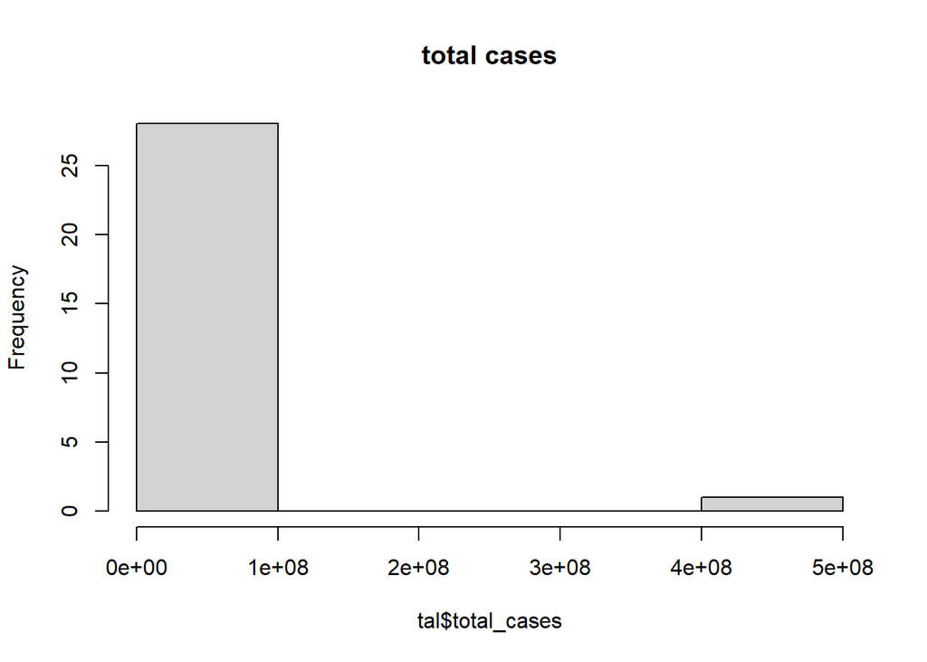

```r
hist(tal$total_cases, main="total cases")
```

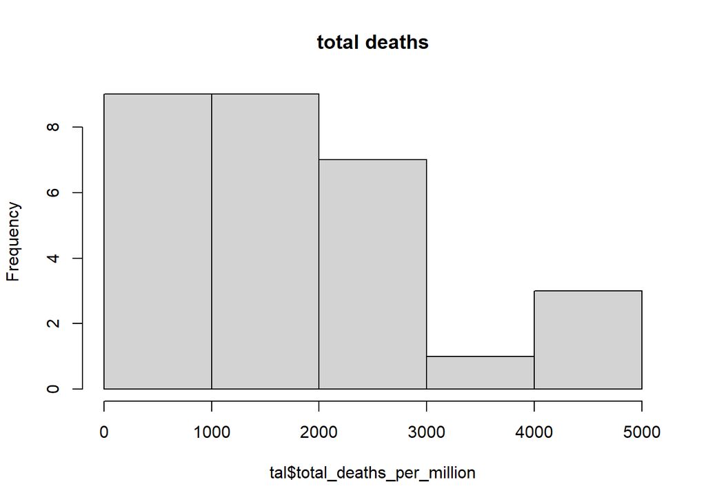

```r
hist(tal$total_deaths_per_million, main="total deaths")
```

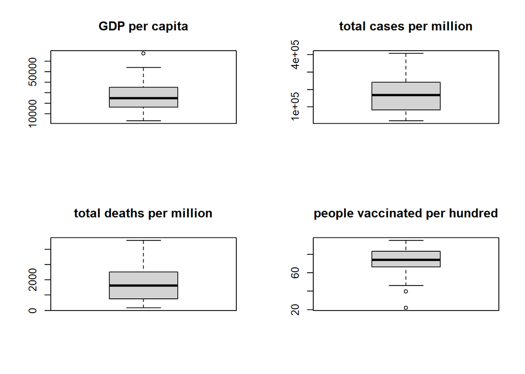

```r
par(mfrow=c(2,2))
boxplot(tal$gdp_per_capita, main="GDP per capita")
boxplot(tal$total_cases_per_million, main="total cases per million")
boxplot(tal$total_deaths_per_million, main="total deaths per million")
boxplot(tal$people_vaccinated_per_hundred, main="people vaccinated per hundred")
```

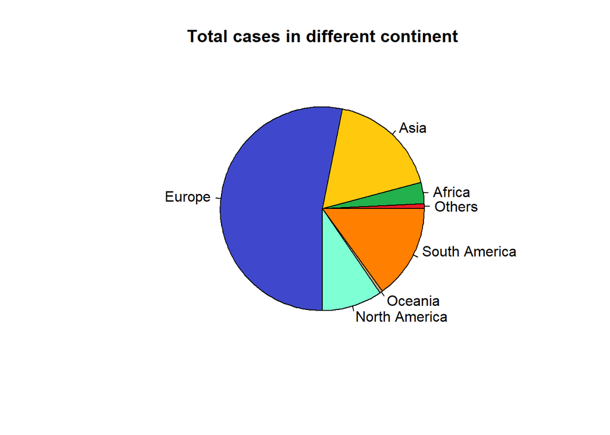

```r
names=c("Others","Africa" ,"Asia", "Europe", "North America", "Oceania", "South America
")
cols = c("#ED1C24","#22B14C","#FFC90E","#3f48CC","#7FFFD4", "#CDAA7D", "#FF7F00")
covid_omit=na.omit(covid_)
tal_case_continent=data.frame(tapply(covid_omit$total_cases_per_million, covid_omit$continent, sum))
tal_case_continent=cbind(tal_case_continent,row.names(tal_case_continent))
tal_death_continent=data.frame(tapply(covid_omit$total_deaths_per_million, covid_omit$continent, sum))
tal_death_continent=cbind(tal_death_continent,row.names(tal_death_continent))
extreme_poverty_continent=data.frame(tapply(covid_omit$extreme_poverty, covid_omit$continent, sum))
extreme_poverty_continent=cbind(extreme_poverty_continent,row.names(extreme_poverty_continent))
pie(tal_case_continent$tapply.covid_omit.total_cases_per_million..covid_omit.continent.., labels=names, col=cols, main="Total cases in different continent" )
```

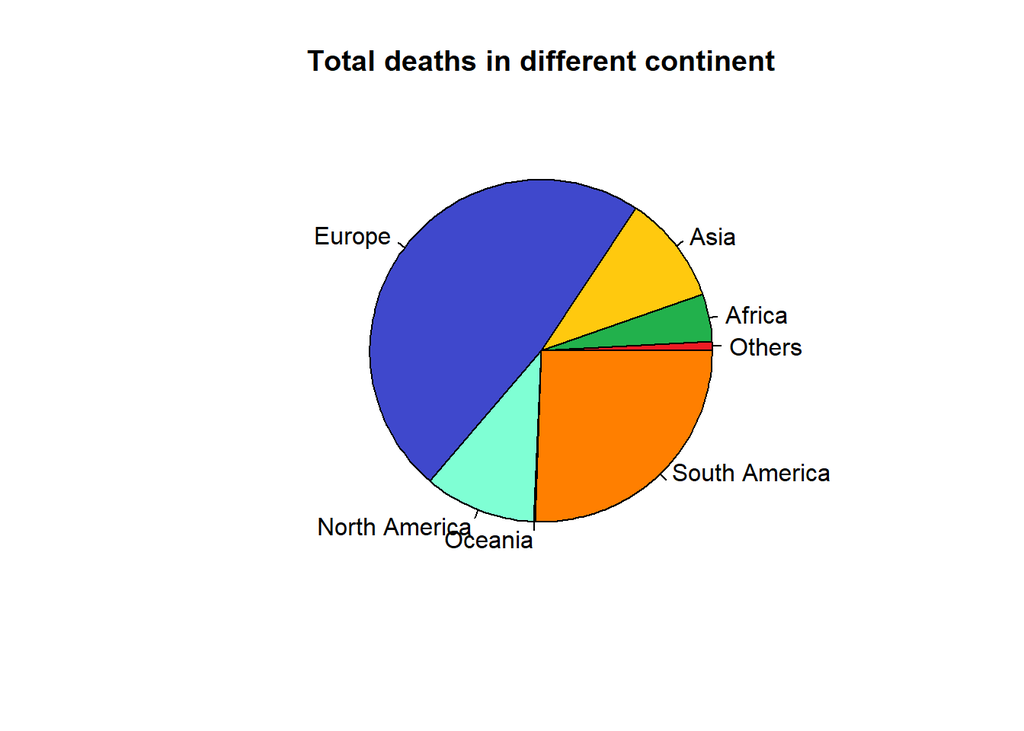

```r
pie(tal_death_continent$tapply.covid_omit.total_deaths_per_million..covid_omit.continent.., labels=names, col=cols,main="Total deaths in different continent")
```

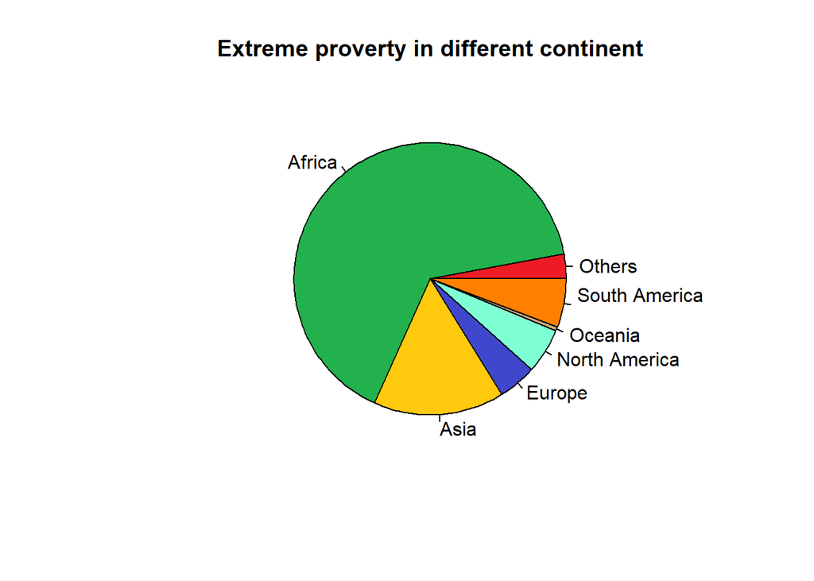

```r
pie(extreme_poverty_continent$tapply.covid_omit.extreme_poverty..covid_omit.continent..sum., labels=names, col=cols,main="Extreme proverty in different continent")
```

# Modeling

Firstly, we are going to explore the relationship between the vaccination rate and the total case per million. First, I tried One-way ANOVA.

```r
tal=na.omit(tal)
lm_total_cases=lm(total_cases_per_million~people_vaccinated_per_hundred,data=tal)
summary(lm_total_cases)
```

```
##
## Call:
## lm(formula = total_cases_per_million ~ people_vaccinated_per_hundred,
##     data = tal)
##
## Residuals:
##     Min      1Q  Median      3Q     Max
## -171598  -93281  -12204   66004  215452
##
## Coefficients:
##                               Estimate Std. Error t value Pr(>|t|)
## (Intercept)                   212368.1   104348.4   2.035   0.0518 .
## people_vaccinated_per_hundred   -479.5     1417.3  -0.338   0.7377
## ---
## Signif. codes:  0 '***' 0.001 '**' 0.01 '*' 0.05 '.' 0.1 ' ' 1
##
## Residual standard error: 119900 on 27 degrees of freedom
## Multiple R-squared:  0.004222,   Adjusted R-squared:  -0.03266
## F-statistic: 0.1145 on 1 and 27 DF,  p-value: 0.7377
```

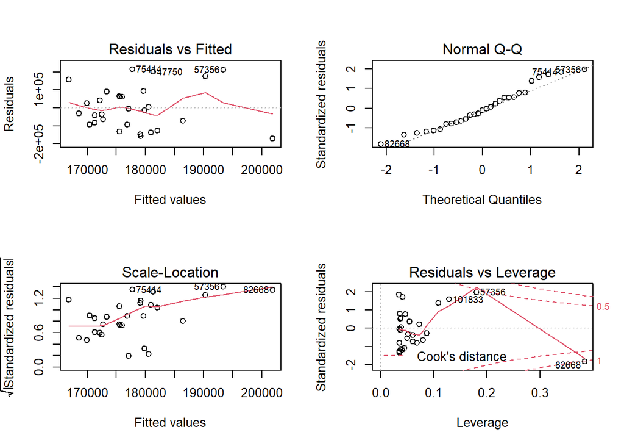

```r
par(mfrow=c(2,2))
plot(lm_total_cases)
```

The qqplot is right skewed. Therefore we do a coxbox transformation to the Y variable.

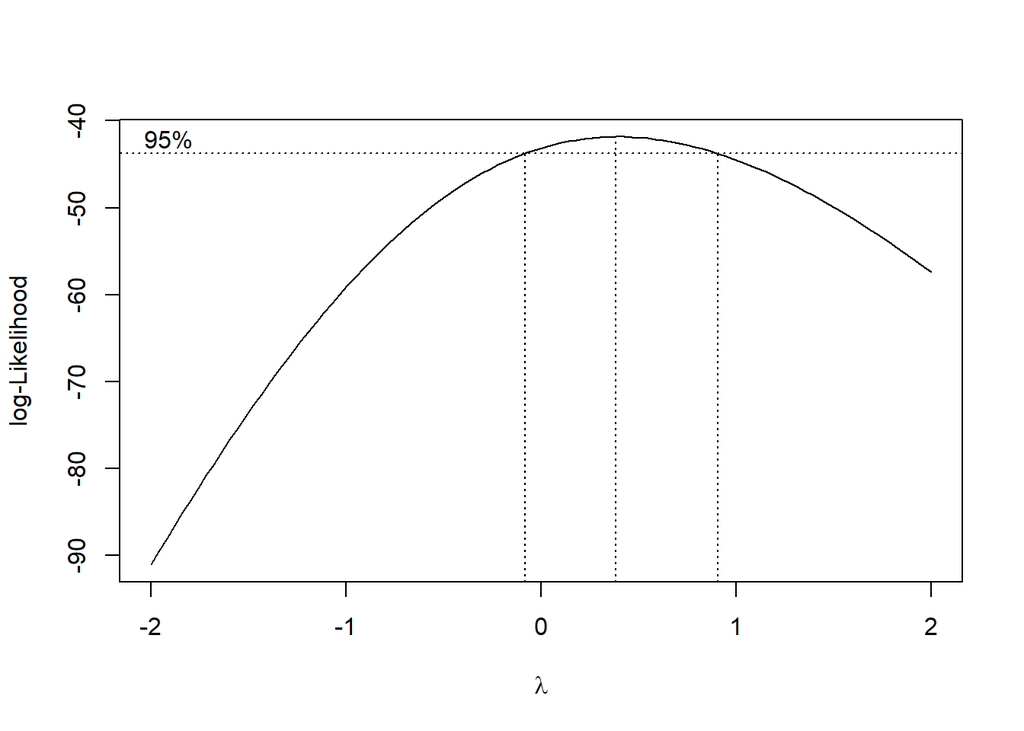

```r
library(MASS)
boxcox(lm_total_cases)
```

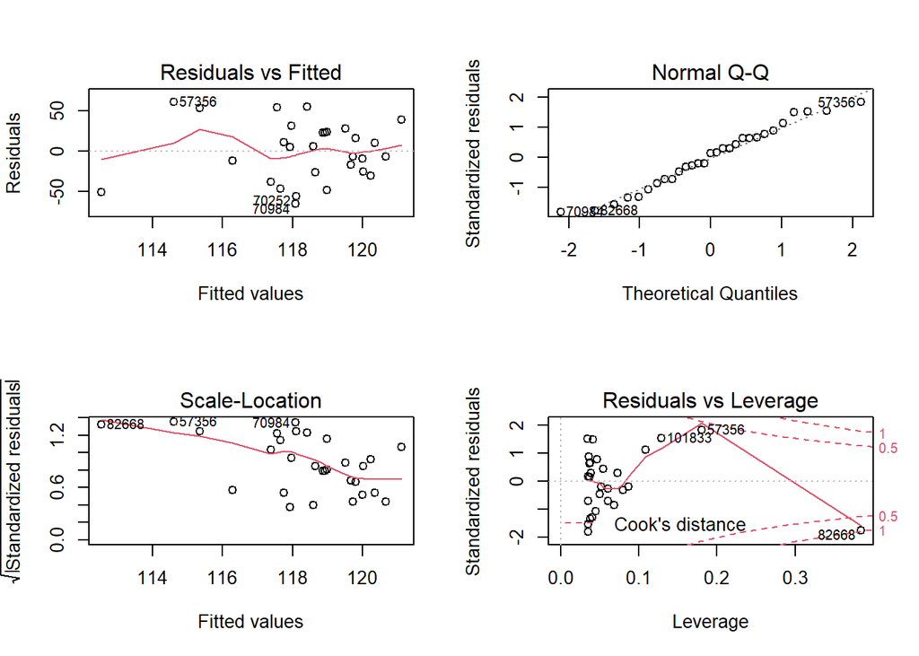

```r
par(mfrow=c(2,2))
lm_total_cases2=lm(I(total_cases_per_million)^0.4~people_vaccinated_per_hundred,data=tal)
plot(lm_total_cases2)
```

```r
anova(lm_total_cases2)
```

```
## Analysis of Variance Table
##
## Response: I(total_cases_per_million)^0.4
##                               Df Sum Sq Mean Sq F value Pr(>F)
## people_vaccinated_per_hundred  1     98   98.41  0.0732 0.7887
## Residuals                     27  36281 1343.72
```

From model lm_total_cases2 we can see that the vaccinated rate isn’t correlated to the infection rate of COVID-19. We will continue to add more variables into the model.

I include the gdp per capita into the model. To see whether GDP per capita have anything to do with the affection rate and the vaccination rate. Firstly, I will test the interation term.

```r
reduced_model=lm(I(total_cases_per_million)^0.4~people_vaccinated_per_hundred+gdp_per_capita, data=tal)
full_model=lm(I(total_cases_per_million)^0.4~people_vaccinated_per_hundred+gdp_per_capita+people_vaccinated_per_hundred*gdp_per_capita, data=tal)
anova(reduced_model,full_model)
```

```
## Analysis of Variance Table
##
## Model 1: I(total_cases_per_million)^0.4 ~ people_vaccinated_per_hundred +
##     gdp_per_capita
## Model 2: I(total_cases_per_million)^0.4 ~ people_vaccinated_per_hundred +
##     gdp_per_capita + people_vaccinated_per_hundred * gdp_per_capita
##   Res.Df   RSS Df Sum of Sq      F Pr(>F)
## 1     26 31267
## 2     25 28611  1    2655.6 2.3204 0.1402
```

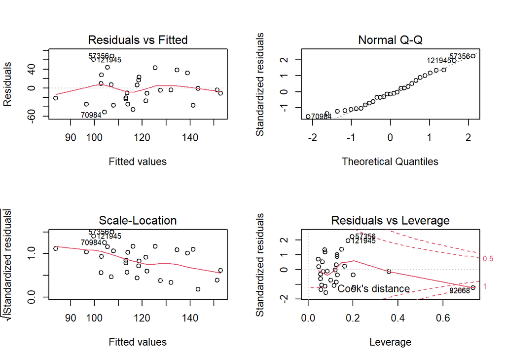

```r
two_way_model=lm(I(total_cases_per_million)^0.4~people_vaccinated_per_hundred+gdp_per_capita+people_vaccinated_per_hundred*gdp_per_capita, data=tal)
par(mfrow=c(2,2))
plot(two_way_model)
```

```r
summary(two_way_model)
```

```
##
## Call:
## lm(formula = I(total_cases_per_million)^0.4 ~ people_vaccinated_per_hundred +
##     gdp_per_capita + people_vaccinated_per_hundred * gdp_per_capita,
##     data = tal)
##
## Residuals:
##     Min      1Q  Median      3Q     Max
## -51.158 -23.016  -4.091  22.894  67.948
##
## Coefficients:
##                                                Estimate Std. Error t value
## (Intercept)                                   6.143e+01  4.835e+01   1.271
## people_vaccinated_per_hundred                 3.627e-01  6.893e-01   0.526
## gdp_per_capita                                5.457e-03  2.930e-03   1.862
## people_vaccinated_per_hundred:gdp_per_capita -5.604e-05  3.679e-05  -1.523
##                                              Pr(>|t|)
## (Intercept)                                    0.2156
## people_vaccinated_per_hundred                  0.6034
## gdp_per_capita                                 0.0744 .
## people_vaccinated_per_hundred:gdp_per_capita   0.1402
## ---
## Signif. codes:  0 '***' 0.001 '**' 0.01 '*' 0.05 '.' 0.1 ' ' 1
##
## Residual standard error: 33.83 on 25 degrees of freedom
## Multiple R-squared:  0.2135, Adjusted R-squared:  0.1191
## F-statistic: 2.262 on 3 and 25 DF,  p-value: 0.1059
```

```r
full_model2=lm(I(total_cases_per_million)^0.5~(tal$people_vaccinated_per_hundred + tal$gdp_per_capita + tal$population_density + median_age +  extreme_poverty)^2,data=tal)
summary(full_model2)
```

```
##
## Call:
## lm(formula = I(total_cases_per_million)^0.5 ~ (tal$people_vaccinated_per_hundred +
##     tal$gdp_per_capita + tal$population_density + median_age +
##     extreme_poverty)^2, data = tal)
##
## Residuals:
##      Min       1Q   Median       3Q      Max
## -189.559  -47.219    0.408   52.987  129.517
##
## Coefficients:
##                                                            Estimate Std. Error
## (Intercept)                                              -3.911e+02  1.009e+03
## tal$people_vaccinated_per_hundred                         5.284e+00  1.633e+01
## tal$gdp_per_capita                                        9.217e-03  4.438e-02
## tal$population_density                                   -1.135e+00  1.909e+00
## median_age                                                2.106e+01  4.118e+01
## extreme_poverty                                          -7.547e+01  1.756e+02
## tal$people_vaccinated_per_hundred:tal$gdp_per_capita     -1.370e-04  3.499e-04
## tal$people_vaccinated_per_hundred:tal$population_density  1.561e-02  3.484e-02
## tal$people_vaccinated_per_hundred:median_age             -3.665e-02  5.525e-01
## tal$people_vaccinated_per_hundred:extreme_poverty        -1.865e+00  1.693e+00
## tal$gdp_per_capita:tal$population_density                 1.322e-04  5.013e-05
## tal$gdp_per_capita:median_age                            -1.610e-04  8.602e-04
## tal$gdp_per_capita:extreme_poverty                        6.294e-04  3.477e-03
## tal$population_density:median_age                        -1.235e-01  7.276e-02
## tal$population_density:extreme_poverty                    2.060e-01  8.956e-02
## median_age:extreme_poverty                                5.369e+00  4.980e+00
##                                                          t value Pr(>|t|)
## (Intercept)                                               -0.388   0.7045
## tal$people_vaccinated_per_hundred                          0.323   0.7515
## tal$gdp_per_capita                                         0.208   0.8387
## tal$population_density                                    -0.594   0.5625
## median_age                                                 0.511   0.6177
## extreme_poverty                                           -0.430   0.6744
## tal$people_vaccinated_per_hundred:tal$gdp_per_capita      -0.392   0.7017
## tal$people_vaccinated_per_hundred:tal$population_density   0.448   0.6615
## tal$people_vaccinated_per_hundred:median_age              -0.066   0.9481
## tal$people_vaccinated_per_hundred:extreme_poverty         -1.102   0.2906
## tal$gdp_per_capita:tal$population_density                  2.638   0.0205 *
## tal$gdp_per_capita:median_age                             -0.187   0.8544
## tal$gdp_per_capita:extreme_poverty                         0.181   0.8591
## tal$population_density:median_age                         -1.698   0.1133
## tal$population_density:extreme_poverty                     2.300   0.0386 *
## median_age:extreme_poverty                                 1.078   0.3006
## ---
## Signif. codes:  0 '***' 0.001 '**' 0.01 '*' 0.05 '.' 0.1 ' ' 1
##
## Residual standard error: 110.1 on 13 degrees of freedom
## Multiple R-squared:  0.7397, Adjusted R-squared:  0.4393
## F-statistic: 2.463 on 15 and 13 DF,  p-value: 0.05519
```

```r
reduced_model=lm(I(total_cases_per_million)^0.4~1,data=tal)
Model.AIC=stepAIC (reduced_model, scope = list(upper = full_model2, lower= ~1, direction = "forward",k = 2,trace=F))
```

```
## Start:  AIC=208.9
## I(total_cases_per_million)^0.4 ~ 1
##
##                                     Df Sum of Sq   RSS    AIC
## + median_age                         1    6532.2 29847 205.16
## + extreme_poverty                    1    5627.6 30751 206.03
## + tal$gdp_per_capita                 1    4271.9 32107 207.28
## <none>                                           36379 208.90
## + tal$population_density             1     337.7 36041 210.63
## + tal$people_vaccinated_per_hundred  1      98.4 36281 210.82
##
## Step:  AIC=205.16
## I(total_cases_per_million)^0.4 ~ median_age
##
##                                     Df Sum of Sq   RSS    AIC
## + extreme_poverty                    1    2412.5 27434 204.72
## <none>                                           29847 205.16
## + tal$population_density             1    1034.8 28812 206.14
## + tal$gdp_per_capita                 1     808.5 29038 206.36
## + tal$people_vaccinated_per_hundred  1     379.6 29467 206.79
## - median_age                         1    6532.2 36379 208.90
##
## Step:  AIC=204.72
## I(total_cases_per_million)^0.4 ~ median_age + extreme_poverty
##
##                                     Df Sum of Sq   RSS    AIC
## + median_age:extreme_poverty         1    2751.6 24683 203.65
## <none>                                           27434 204.72
## - extreme_poverty                    1    2412.5 29847 205.16
## - median_age                         1    3317.1 30751 206.03
## + tal$population_density             1     558.1 26876 206.12
## + tal$people_vaccinated_per_hundred  1     443.4 26991 206.24
## + tal$gdp_per_capita                 1     226.6 27208 206.47
##
## Step:  AIC=203.65
## I(total_cases_per_million)^0.4 ~ median_age + extreme_poverty +
##     median_age:extreme_poverty
##
##                                     Df Sum of Sq   RSS    AIC
## <none>                                           24683 203.65
## + tal$gdp_per_capita                 1    908.53 23774 204.56
## - median_age:extreme_poverty         1   2751.62 27434 204.72
## + tal$population_density             1     76.72 24606 205.56
## + tal$people_vaccinated_per_hundred  1     32.23 24650 205.61
```

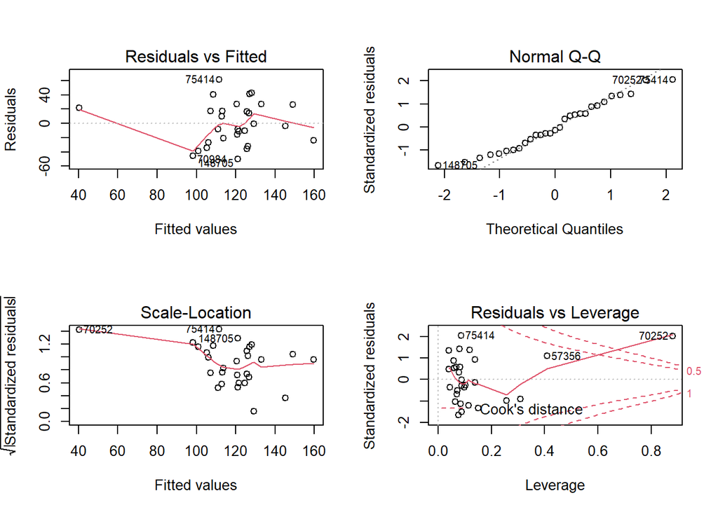

```r
par(mfrow=c(2,2))
plot(Model.AIC)
```

```r
summary(Model.AIC)
```

```
##
## Call:
## lm(formula = I(total_cases_per_million)^0.4 ~ median_age + extreme_poverty +
##     median_age:extreme_poverty, data = tal)
##
## Residuals:
##     Min      1Q  Median      3Q     Max
## -50.045 -24.073  -3.846  22.143  61.488
##
## Coefficients:
##                            Estimate Std. Error t value Pr(>|t|)
## (Intercept)                 84.8073    42.0535   2.017   0.0546 .
## median_age                   0.8851     1.1571   0.765   0.4515
## extreme_poverty            -31.1615    17.3230  -1.799   0.0841 .
## median_age:extreme_poverty   0.9888     0.5923   1.669   0.1075
## ---
## Signif. codes:  0 '***' 0.001 '**' 0.01 '*' 0.05 '.' 0.1 ' ' 1
##
## Residual standard error: 31.42 on 25 degrees of freedom
## Multiple R-squared:  0.3215, Adjusted R-squared:  0.2401
## F-statistic: 3.949 on 3 and 25 DF,  p-value: 0.0196
```

Linear model of new cases

```r
covid_week$new_cases_smoothed_per_million[which(covid_week$new_cases_smoothed_per_million==0)]=0.01
covid_week$new_deaths_smoothed[which(covid_week$new_deaths_smoothed==0)]=0.01
```

```r
model_new_cases=lm(covid_week$new_cases_smoothed_per_million~covid_week$week+covid_week$people_vaccinated_per_hundred+covid_week$median_age+covid_week$gdp_per_capita+covid_week$gdp_per_capita+covid_week$population_density+covid_week$extreme_poverty)
```

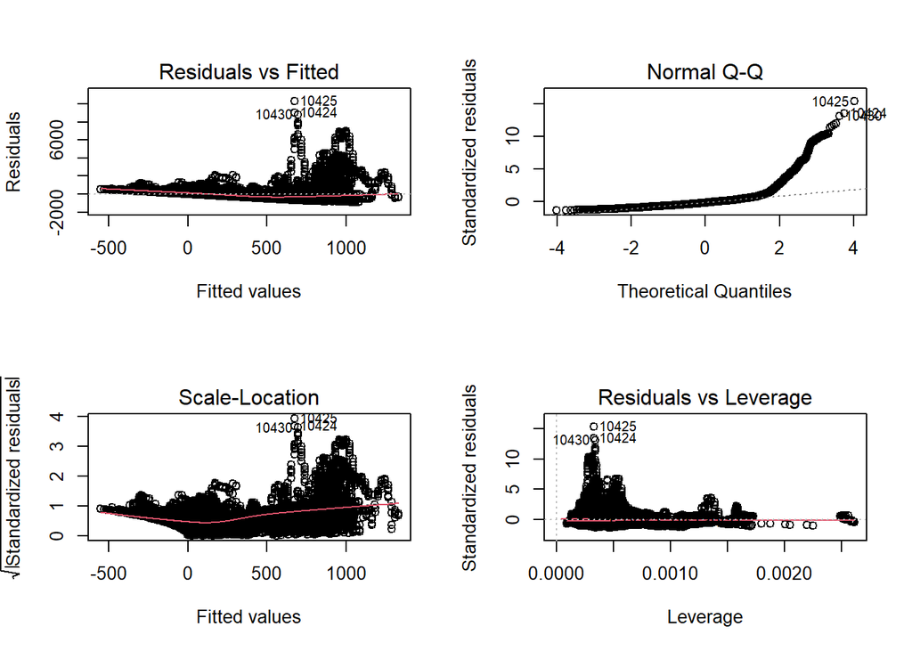

```r
par(mfrow=c(2,2))
plot(model_new_cases)
```

I did a box-cox transformation to the new cases detected everyday to make the new case to be normal distributed.

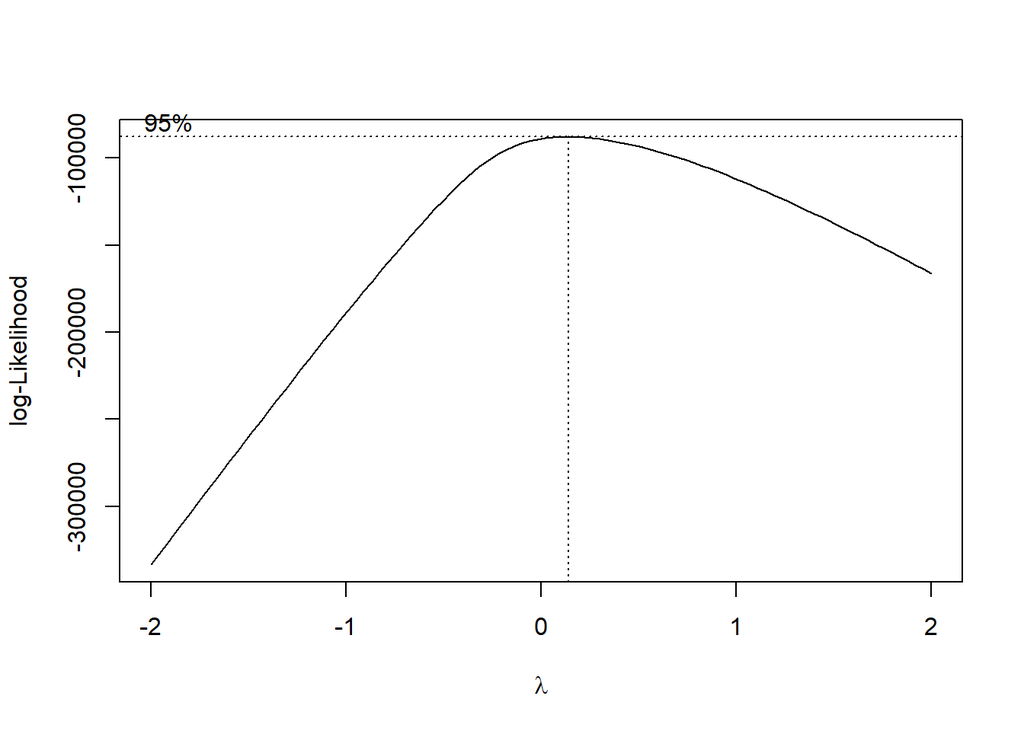

```r
library("MASS")
boxcox(model_new_cases)
```

```r
model_new_cases2=lm(I(covid_week$new_cases_smoothed_per_million)^0.1~covid_week$week+covid_week$people_vaccinated_per_hundred+covid_week$median_age+covid_week$gdp_per_capita+covid_week$gdp_per_capita)
```

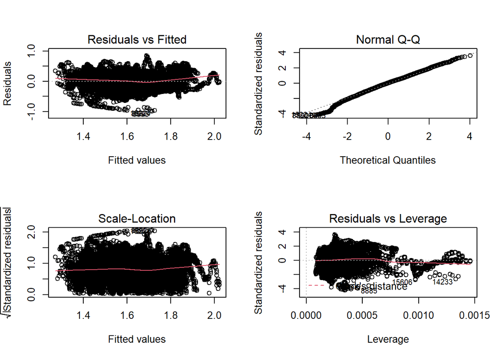

```r
par(mfrow=c(2,2))
plot(model_new_cases2)
```

```r
summary(model_new_cases2)
```

```
##
## Call:
## lm(formula = I(covid_week$new_cases_smoothed_per_million)^0.1 ~
##     covid_week$week + covid_week$people_vaccinated_per_hundred +
##         covid_week$median_age + covid_week$gdp_per_capita + covid_week$gdp_per_capita)
##
## Residuals:
##      Min       1Q   Median       3Q      Max
## -0.99272 -0.15169  0.00968  0.14998  0.84721
##
## Coefficients:
##                                            Estimate Std. Error t value Pr(>|t|)
## (Intercept)                               6.791e-01  1.837e-02  36.965   <2e-16
## covid_week$week                           6.006e-03  1.976e-04  30.387   <2e-16
## covid_week$people_vaccinated_per_hundred -1.008e-03  1.218e-04  -8.279   <2e-16
## covid_week$median_age                     1.108e-02  2.946e-04  37.613   <2e-16
## covid_week$gdp_per_capita                 3.375e-06  1.221e-07  27.648   <2e-16
##
## (Intercept)                              ***
## covid_week$week                          ***
## covid_week$people_vaccinated_per_hundred ***
## covid_week$median_age                    ***
## covid_week$gdp_per_capita                ***
## ---
## Signif. codes:  0 '***' 0.001 '**' 0.01 '*' 0.05 '.' 0.1 ' ' 1
##
## Residual standard error: 0.2347 on 16821 degrees of freedom
## Multiple R-squared:  0.2388, Adjusted R-squared:  0.2386
## F-statistic:  1319 on 4 and 16821 DF,  p-value: < 2.2e-16
```

```r
model_new_cases3_2=lm(I(covid_week$new_cases_smoothed_per_million)^0.1~(covid_week$week+covid_week$people_vaccinated_per_hundred+covid_week$median_age+covid_week$gdp_per_capita+covid_week$gdp_per_capita)^2)
```

```r
reduced_model2=lm(I(covid_week$new_cases_smoothed_per_million)^0.1~1)
Model.AIC2=stepAIC (reduced_model2, scope = list(upper = model_new_cases3_2, lower= ~1, direction = "both",k = 2,trace=F))
```

```
## Start:  AIC=-44185.42
## I(covid_week$new_cases_smoothed_per_million)^0.1 ~ 1
##
##                                            Df Sum of Sq    RSS    AIC
## + covid_week$median_age                     1   151.309 1066.2 -46416
## + covid_week$gdp_per_capita                 1   128.357 1089.1 -46058
## + covid_week$people_vaccinated_per_hundred  1   108.815 1108.7 -45759
## + covid_week$week                           1    68.294 1149.2 -45155
## <none>                                                  1217.5 -44185
##
## Step:  AIC=-46416.38
## I(covid_week$new_cases_smoothed_per_million)^0.1 ~ covid_week$median_age
##
##                                            Df Sum of Sq     RSS    AIC
## + covid_week$week                           1    96.103  970.07 -48004
## + covid_week$people_vaccinated_per_hundred  1    72.177  994.00 -47594
## + covid_week$gdp_per_capita                 1    36.761 1029.41 -47005
## <none>                                                  1066.17 -46416
## - covid_week$median_age                     1   151.309 1217.48 -44185
##
## Step:  AIC=-48003.81
## I(covid_week$new_cases_smoothed_per_million)^0.1 ~ covid_week$median_age +
##     covid_week$week
##
##                                            Df Sum of Sq     RSS    AIC
## + covid_week$gdp_per_capita                 1    39.552  930.52 -48702
## + covid_week$week:covid_week$median_age     1    19.051  951.02 -48336
## + covid_week$people_vaccinated_per_hundred  1     1.213  968.86 -48023
## <none>                                                   970.07 -48004
## - covid_week$week                           1    96.103 1066.17 -46416
## - covid_week$median_age                     1   179.117 1149.19 -45155
##
## Step:  AIC=-48702.22
## I(covid_week$new_cases_smoothed_per_million)^0.1 ~ covid_week$median_age +
##     covid_week$week + covid_week$gdp_per_capita
##
##                                                   Df Sum of Sq     RSS    AIC
## + covid_week$median_age:covid_week$gdp_per_capita  1    41.198  889.32 -49462
## + covid_week$week:covid_week$median_age            1    17.404  913.12 -49018
## + covid_week$week:covid_week$gdp_per_capita        1    12.187  918.33 -48922
```

[output cut: 217 more lines]

```
## <none>                                                               784.19
## - covid_week$median_age:covid_week$people_vaccinated_per_hundred     784.47
## - covid_week$median_age:covid_week$week                              788.66
## - covid_week$gdp_per_capita:covid_week$people_vaccinated_per_hundred 791.08
## - covid_week$week:covid_week$gdp_per_capita                          791.91
## - covid_week$median_age:covid_week$gdp_per_capita                    797.17
## - covid_week$week:covid_week$people_vaccinated_per_hundred           817.82
##                                                                         AIC
## <none>                                                               -51567
## - covid_week$median_age:covid_week$people_vaccinated_per_hundred     -51563
## - covid_week$median_age:covid_week$week                              -51473
## - covid_week$gdp_per_capita:covid_week$people_vaccinated_per_hundred -51422
## - covid_week$week:covid_week$gdp_per_capita                          -51404
## - covid_week$median_age:covid_week$gdp_per_capita                    -51293
## - covid_week$week:covid_week$people_vaccinated_per_hundred           -50862
```

```r
summary(Model.AIC2)
```

```
##
## Call:
## lm(formula = I(covid_week$new_cases_smoothed_per_million)^0.1 ~
##     covid_week$median_age + covid_week$week + covid_week$gdp_per_capita +
##         covid_week$people_vaccinated_per_hundred + covid_week$median_age:covid_week$gdp_per_capita +
##         covid_week$median_age:covid_week$week + covid_week$week:covid_week$people_vaccinated_per_hundred +
##         covid_week$median_age:covid_week$people_vaccinated_per_hundred +
##         covid_week$week:covid_week$gdp_per_capita + covid_week$gdp_per_capita:covid_week$people_vaccinated_per_hundred)
##
## Residuals:
##      Min       1Q   Median       3Q      Max
## -1.16018 -0.13714  0.00912  0.14439  0.71138
##
## Coefficients:
##                                                                      Estimate
## (Intercept)                                                         1.793e+00
## covid_week$median_age                                              -3.467e-03
## covid_week$week                                                    -1.249e-02
## covid_week$gdp_per_capita                                           1.386e-05
## covid_week$people_vaccinated_per_hundred                           -8.475e-03
## covid_week$median_age:covid_week$gdp_per_capita                    -5.224e-07
## covid_week$median_age:covid_week$week                               2.809e-04
## covid_week$week:covid_week$people_vaccinated_per_hundred            1.327e-04
## covid_week$median_age:covid_week$people_vaccinated_per_hundred     -4.605e-05
## covid_week$week:covid_week$gdp_per_capita                           1.698e-07
## covid_week$gdp_per_capita:covid_week$people_vaccinated_per_hundred -9.748e-08
##                                                                    Std. Error
## (Intercept)                                                         7.403e-02
## covid_week$median_age                                               2.124e-03
## covid_week$week                                                     9.626e-04
## covid_week$gdp_per_capita                                           1.437e-06
## covid_week$people_vaccinated_per_hundred                            7.946e-04
## covid_week$median_age:covid_week$gdp_per_capita                     3.132e-08
## covid_week$median_age:covid_week$week                               2.868e-05
## covid_week$week:covid_week$people_vaccinated_per_hundred            4.940e-06
## covid_week$median_age:covid_week$people_vaccinated_per_hundred      1.879e-05
## covid_week$week:covid_week$gdp_per_capita                           1.320e-08
## covid_week$gdp_per_capita:covid_week$people_vaccinated_per_hundred  8.019e-09
##                                                                    t value
## (Intercept)                                                         24.226
```

[output cut: 13 more lines]

```
## covid_week$week                                                      <2e-16 ***
## covid_week$gdp_per_capita                                            <2e-16 ***
## covid_week$people_vaccinated_per_hundred                             <2e-16 ***
## covid_week$median_age:covid_week$gdp_per_capita                      <2e-16 ***
## covid_week$median_age:covid_week$week                                <2e-16 ***
## covid_week$week:covid_week$people_vaccinated_per_hundred             <2e-16 ***
## covid_week$median_age:covid_week$people_vaccinated_per_hundred       0.0143 *
## covid_week$week:covid_week$gdp_per_capita                            <2e-16 ***
## covid_week$gdp_per_capita:covid_week$people_vaccinated_per_hundred   <2e-16 ***
## ---
## Signif. codes:  0 '***' 0.001 '**' 0.01 '*' 0.05 '.' 0.1 ' ' 1
##
## Residual standard error: 0.216 on 16815 degrees of freedom
## Multiple R-squared:  0.3559, Adjusted R-squared:  0.3555
## F-statistic: 929.1 on 10 and 16815 DF,  p-value: < 2.2e-16
```

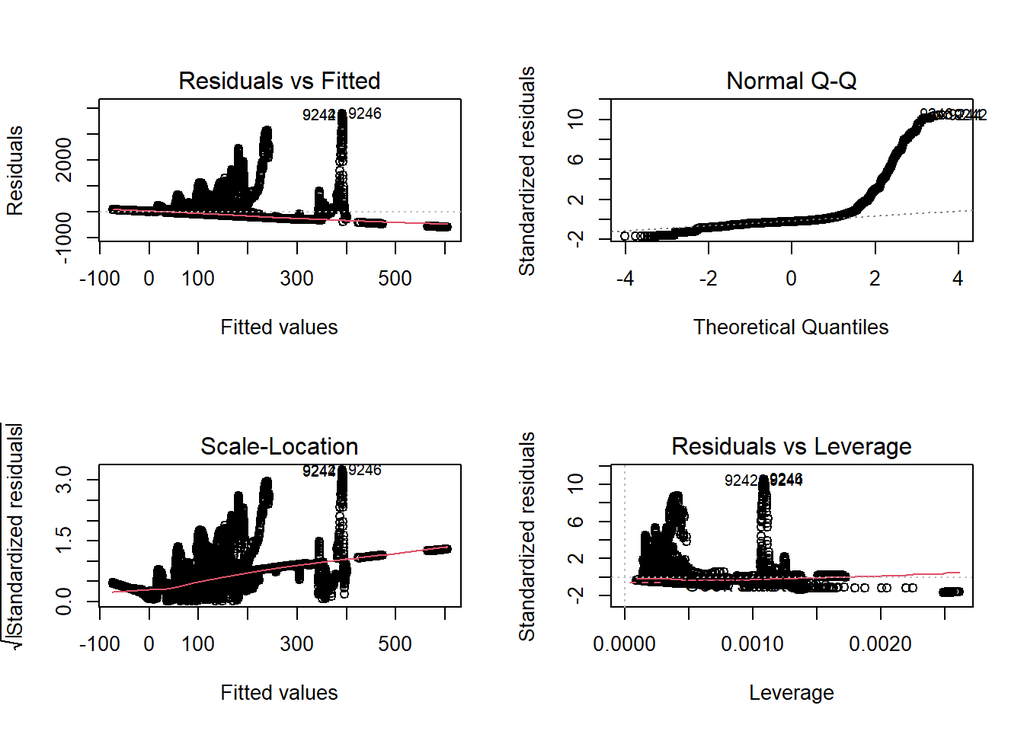

```r
model_new_death=lm(covid_week$new_deaths_smoothed~covid_week$week+covid_week$people_vaccinated_per_hundred+covid_week$median_age+covid_week$gdp_per_capita+covid_week$gdp_per_capita+covid_week$population_density+covid_week$extreme_poverty)
par(mfrow=c(2,2))
plot(model_new_death)
```

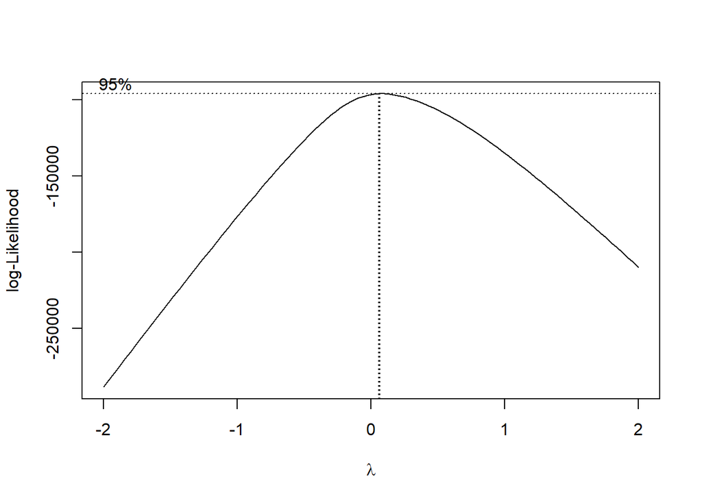

```r
boxcox(model_new_death)
```

```r
model_new_death2=lm(log(covid_week$new_deaths_smoothed)~covid_week$week+covid_week$people_vaccinated_per_hundred+covid_week$median_age+covid_week$gdp_per_capita+covid_week$gdp_per_capita+covid_week$population_density+covid_week$extreme_poverty)
```

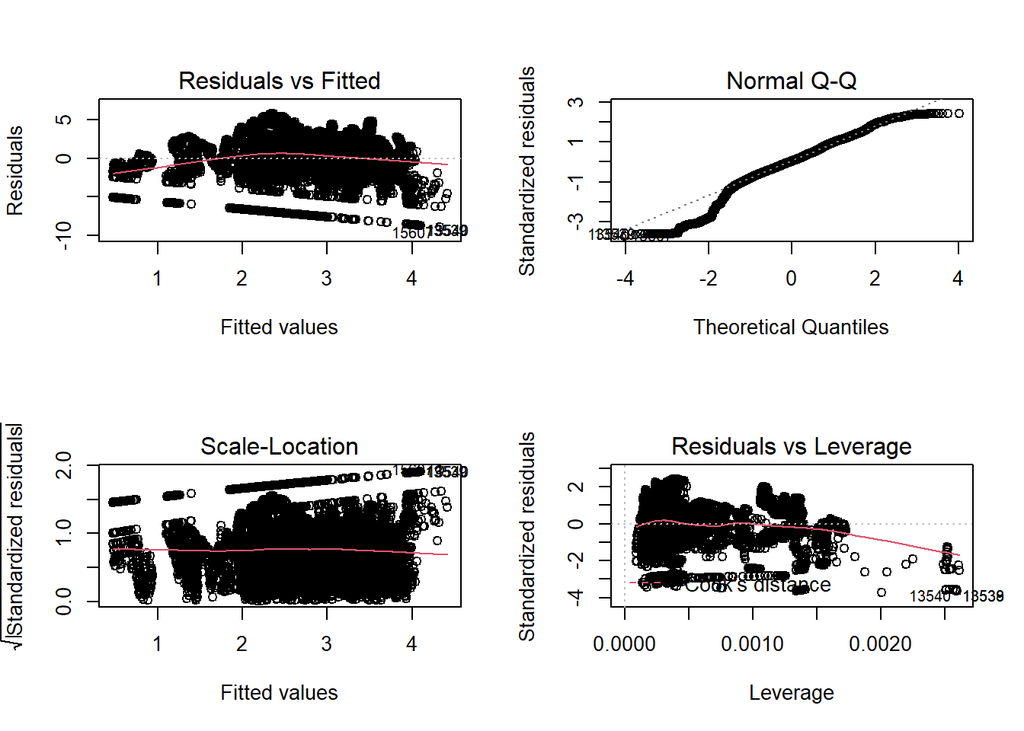

```r
par(mfrow=c(2,2))
plot(model_new_death2)
```

```r
summary(model_new_death2)
```

```
##
## Call:
## lm(formula = log(covid_week$new_deaths_smoothed) ~ covid_week$week +
##     covid_week$people_vaccinated_per_hundred + covid_week$median_age +
##     covid_week$gdp_per_capita + covid_week$gdp_per_capita + covid_week$population_density +
##     covid_week$extreme_poverty)
##
## Residuals:
##     Min      1Q  Median      3Q     Max
## -8.9338 -1.2442  0.0777  1.5544  5.7791
##
## Coefficients:
##                                            Estimate Std. Error t value Pr(>|t|)
## (Intercept)                              -1.352e-01  1.970e-01  -0.686    0.493
## covid_week$week                           1.827e-02  2.050e-03   8.910   <2e-16
## covid_week$people_vaccinated_per_hundred -1.254e-02  1.275e-03  -9.831   <2e-16
## covid_week$median_age                     6.845e-02  3.177e-03  21.547   <2e-16
## covid_week$gdp_per_capita                -1.930e-05  1.267e-06 -15.232   <2e-16
## covid_week$population_density            -1.433e-03  7.028e-05 -20.392   <2e-16
## covid_week$extreme_poverty                6.381e-02  4.680e-03  13.636   <2e-16
##
## (Intercept)
## covid_week$week                          ***
## covid_week$people_vaccinated_per_hundred ***
## covid_week$median_age                    ***
## covid_week$gdp_per_capita                ***
## covid_week$population_density            ***
## covid_week$extreme_poverty               ***
## ---
## Signif. codes:  0 '***' 0.001 '**' 0.01 '*' 0.05 '.' 0.1 ' ' 1
##
## Residual standard error: 2.399 on 16819 degrees of freedom
## Multiple R-squared:  0.07786,    Adjusted R-squared:  0.07753
## F-statistic: 236.7 on 6 and 16819 DF,  p-value: < 2.2e-16
```

```r
model_new_death3=lm(log(covid_week$new_deaths_smoothed)~(covid_week$week+covid_week$people_vaccinated_per_hundred+covid_week$median_age+covid_week$gdp_per_capita+covid_week$gdp_per_capita)^2)
```

```r
reduced_model3=lm(log(covid_week$new_deaths_smoothed)~1)
Model.AIC3=stepAIC (reduced_model3, scope = list(upper = model_new_death3, lower= ~1, direction = "both",k = 2,trace=F))
```

```
## Start:  AIC=30805.83
## log(covid_week$new_deaths_smoothed) ~ 1
##
##                                            Df Sum of Sq    RSS   AIC
## + covid_week$gdp_per_capita                 1   2125.41 102842 30464
## + covid_week$people_vaccinated_per_hundred  1    937.55 104030 30657
## + covid_week$median_age                     1    206.66 104761 30775
## <none>                                                  104968 30806
## + covid_week$week                           1      1.78 104966 30808
##
## Step:  AIC=30463.64
## log(covid_week$new_deaths_smoothed) ~ covid_week$gdp_per_capita
##
##                                            Df Sum of Sq    RSS   AIC
## + covid_week$median_age                     1   1811.11 101031 30167
## + covid_week$people_vaccinated_per_hundred  1    311.03 102531 30415
## <none>                                                  102842 30464
## + covid_week$week                           1      5.25 102837 30465
## - covid_week$gdp_per_capita                 1   2125.41 104968 30806
##
## Step:  AIC=30166.69
## log(covid_week$new_deaths_smoothed) ~ covid_week$gdp_per_capita +
##     covid_week$median_age
##
##                                                   Df Sum of Sq    RSS   AIC
## + covid_week$median_age:covid_week$gdp_per_capita  1    2327.5  98704 29777
## + covid_week$people_vaccinated_per_hundred         1     348.3 100683 30111
## <none>                                                         101031 30167
## + covid_week$week                                  1       2.8 101028 30168
## - covid_week$median_age                            1    1811.1 102842 30464
## - covid_week$gdp_per_capita                        1    3729.9 104761 30775
##
## Step:  AIC=29776.53
## log(covid_week$new_deaths_smoothed) ~ covid_week$gdp_per_capita +
##     covid_week$median_age + covid_week$gdp_per_capita:covid_week$median_age
##
##                                                   Df Sum of Sq    RSS   AIC
## + covid_week$people_vaccinated_per_hundred         1    462.21  98242 29700
## <none>                                                          98704 29777
## + covid_week$week                                  1      2.00  98702 29778
```

[output cut: 270 more lines]

```
## <none>                                                               92774
## - covid_week$median_age:covid_week$week                              92825
## - covid_week$gdp_per_capita:covid_week$week                          92905
## - covid_week$median_age:covid_week$people_vaccinated_per_hundred     93084
## - covid_week$gdp_per_capita:covid_week$people_vaccinated_per_hundred 93132
## - covid_week$gdp_per_capita:covid_week$median_age                    94778
## - covid_week$people_vaccinated_per_hundred:covid_week$week           95007
##                                                                        AIC
## <none>                                                               28748
## - covid_week$median_age:covid_week$week                              28755
## - covid_week$gdp_per_capita:covid_week$week                          28770
## - covid_week$median_age:covid_week$people_vaccinated_per_hundred     28802
## - covid_week$gdp_per_capita:covid_week$people_vaccinated_per_hundred 28811
## - covid_week$gdp_per_capita:covid_week$median_age                    29106
## - covid_week$people_vaccinated_per_hundred:covid_week$week           29146
```

```r
summary(Model.AIC3)
```

```
##
## Call:
## lm(formula = log(covid_week$new_deaths_smoothed) ~ covid_week$gdp_per_capita +
##     covid_week$median_age + covid_week$people_vaccinated_per_hundred +
##     covid_week$week + covid_week$gdp_per_capita:covid_week$median_age +
##     covid_week$people_vaccinated_per_hundred:covid_week$week +
##     covid_week$median_age:covid_week$people_vaccinated_per_hundred +
##     covid_week$gdp_per_capita:covid_week$people_vaccinated_per_hundred +
##     covid_week$gdp_per_capita:covid_week$week + covid_week$median_age:covid_week$week)
##
## Residuals:
##     Min      1Q  Median      3Q     Max
## -9.2393 -1.3425  0.0837  1.5072  5.8646
##
## Coefficients:
##                                                                      Estimate
## (Intercept)                                                        -1.085e+00
## covid_week$gdp_per_capita                                           2.001e-04
## covid_week$median_age                                               1.799e-01
## covid_week$people_vaccinated_per_hundred                           -1.475e-01
## covid_week$week                                                     6.473e-03
## covid_week$gdp_per_capita:covid_week$median_age                    -6.492e-06
## covid_week$people_vaccinated_per_hundred:covid_week$week            1.081e-03
## covid_week$median_age:covid_week$people_vaccinated_per_hundred      1.533e-03
## covid_week$gdp_per_capita:covid_week$people_vaccinated_per_hundred -7.026e-07
## covid_week$gdp_per_capita:covid_week$week                           6.989e-07
## covid_week$median_age:covid_week$week                              -9.459e-04
##                                                                    Std. Error
## (Intercept)                                                         8.052e-01
## covid_week$gdp_per_capita                                           1.563e-05
## covid_week$median_age                                               2.311e-02
## covid_week$people_vaccinated_per_hundred                            8.643e-03
## covid_week$week                                                     1.047e-02
## covid_week$gdp_per_capita:covid_week$median_age                     3.406e-07
## covid_week$people_vaccinated_per_hundred:covid_week$week            5.373e-05
## covid_week$median_age:covid_week$people_vaccinated_per_hundred      2.044e-04
## covid_week$gdp_per_capita:covid_week$people_vaccinated_per_hundred  8.723e-08
## covid_week$gdp_per_capita:covid_week$week                           1.435e-07
## covid_week$median_age:covid_week$week                               3.120e-04
##                                                                    t value
```

[output cut: 14 more lines]

```
## covid_week$median_age                                              7.36e-15 ***
## covid_week$people_vaccinated_per_hundred                            < 2e-16 ***
## covid_week$week                                                     0.53646
## covid_week$gdp_per_capita:covid_week$median_age                     < 2e-16 ***
## covid_week$people_vaccinated_per_hundred:covid_week$week            < 2e-16 ***
## covid_week$median_age:covid_week$people_vaccinated_per_hundred     6.75e-14 ***
## covid_week$gdp_per_capita:covid_week$people_vaccinated_per_hundred 8.48e-16 ***
## covid_week$gdp_per_capita:covid_week$week                          1.13e-06 ***
## covid_week$median_age:covid_week$week                               0.00243 **
## ---
## Signif. codes:  0 '***' 0.001 '**' 0.01 '*' 0.05 '.' 0.1 ' ' 1
##
## Residual standard error: 2.349 on 16815 degrees of freedom
## Multiple R-squared:  0.1162, Adjusted R-squared:  0.1156
## F-statistic:   221 on 10 and 16815 DF,  p-value: < 2.2e-16
```

# result

From the box-plot we can tell that the amount of total cases, death cases, and GDP level are very different in different countries and continents. Therefore we well go on to explore the relationships between these variables. The pie plot also show that the poverty rate and the poverty rate, the affection rate and the death rate are very different in different continents.

In Model.AIC. It seems that in the model selected by AIC method. The total effected numbers are most correlated with the median age and the extreme poverty rate of the country.

Model_new_cases2 doesn’t include any interaction terms. It gives the prediction of the new case that are detected based on the time, vaccinated rate, median age and the gdp level. The estimators show that New detected cases increase over time and decrease when the vaccinated rate is higher. Countries with high median age tend to have more detected cases. GDP also have a positive affect to the number of new cases. The reason may be countries with higher GDP may have a better medical system which help to detect and report new cases.

In model_new_death2 we can see that the new death increase during the time. Death are less in those countries with a higher vaccination rate and will be higher in countries with larger median age. Better economic can also help to lower the death rate.